# Statistics I: Technology help — Python

Author: Luc Hens

Version: 14 January 2022

Description: Python code for an introductory applied statistics course.

## Module 1: Data and decisions

The `pandas` library (https://pandas.pydata.org/) is one of the workhorses for data analysis:

```python
import pandas as pd    # imports the pandas library and assigns it the alias pd
```

The command `dir(pd)` will list all of the attributes of the pandas library. To get detailed information on an attribute of a library (for instance, on the `read_csv` attribute), use: `help(pd.read_csv)`. Alternatively, enter pandas & documentation in a search engine to get to the on-line help (https://pandas.pydata.org/docs/). After having worked through the examples in this notebook, you may want to work through the **Getting Started Tutorial** on pandas: https://pandas.pydata.org/docs/getting_started/intro_tutorials/index.html

To import a text file with data in Python, you first have find the path to the file. The data file students.csv used un the example is stored on my web site: https://luc-hens.github.io/students.csv Usually, you will have your data file stored on your computer. In that case you have to give the path to that file, which looks something like: `/Users/yourname/Documents/Data/students.csv` in macOS and `C:/Users/yourname/Documents/Data/students.csv` in Windows (in Windows, make sure to use slashes `/` in the path).

It is good practice to not have spaces in a csv file. The `pandas` command `read_csv` has an option `skipinitialspace=True` ("Skip spaces after delimiter") but that does not solve all the problems caused by blank spaces in a csv file.

```python
import pandas as pd
df = pd.read_csv('https://luc-hens.github.io/students.csv', sep=',',
                 skipinitialspace=True)   # df is the name we assign to the data frame
print(df)
display(df)
```

```
    case     sex  height  weight                  major
0      1  Female     172      63               Business
1      2  Female     170      70  International Affairs
2      3  Female     170      52                  Other
3      4  Female     171      52         Communications
4      5    Male     186      90               Business
5      6    Male     183      79               Business
6      7    Male     170      66         Communications
7      8  Female     169      56               Business
8      9    Male     175      75  International Affairs
9     10  Female     175      65         Communications
10    11    Male     195      94               Business
11    12  Female     176      51  International Affairs
12    13    Male     188      76  International Affairs
13    14    Male     192      82               Business
```

[output cut: 16 more lines]

|  | case | sex | height | weight | major |
| --- | --- | --- | --- | --- | --- |
| 0 | 1 | Female | 172 | 63 | Business |
| 1 | 2 | Female | 170 | 70 | International Affairs |
| 2 | 3 | Female | 170 | 52 | Other |
| 3 | 4 | Female | 171 | 52 | Communications |
| 4 | 5 | Male | 186 | 90 | Business |
| 5 | 6 | Male | 183 | 79 | Business |
| 6 | 7 | Male | 170 | 66 | Communications |
| 7 | 8 | Female | 169 | 56 | Business |
| 8 | 9 | Male | 175 | 75 | International Affairs |
| 9 | 10 | Female | 175 | 65 | Communications |
| 10 | 11 | Male | 195 | 94 | Business |
| 11 | 12 | Female | 176 | 51 | International Affairs |
| 12 | 13 | Male | 188 | 76 | International Affairs |
| 13 | 14 | Male | 192 | 82 | Business |
| 14 | 15 | Male | 172 | 70 | International Affairs |
| 15 | 16 | Female | 169 | 53 | Business |
| 16 | 17 | Female | 172 | 52 | International Affairs |
| 17 | 18 | Male | 178 | 85 | Business |
| 18 | 19 | Female | 177 | 59 | Communications |
| 19 | 20 | Male | 178 | 72 | International Affairs |
| 20 | 21 | Female | 160 | 54 | Business |
| 21 | 22 | Female | 175 | 54 | International Affairs |
| 22 | 23 | Male | 190 | 70 | International Affairs |
| 23 | 24 | Male | 178 | 85 | Business |
| 24 | 25 | Female | 163 | 55 | Business |
| 25 | 26 | Female | 161 | 59 | Business |
| 26 | 27 | Female | 162 | 44 | Communications |
| 27 | 28 | Female | 170 | 54 | Business |
| 28 | 29 | Female | 154 | 52 | Business |
| 29 | 30 | Female | 170 | 65 | Business |

To display just the first couple of lines of the data frame called df:

```python
df.head()
```

|  | case | sex | height | weight | major |
| --- | --- | --- | --- | --- | --- |
| 0 | 1 | Female | 172 | 63 | Business |
| 1 | 2 | Female | 170 | 70 | International Affairs |
| 2 | 3 | Female | 170 | 52 | Other |
| 3 | 4 | Female | 171 | 52 | Communications |
| 4 | 5 | Male | 186 | 90 | Business |

To display the last couple of lines of the data frame called df:

```python
df.tail()
```

|  | case | sex | height | weight | major |
| --- | --- | --- | --- | --- | --- |
| 25 | 26 | Female | 161 | 59 | Business |
| 26 | 27 | Female | 162 | 44 | Communications |
| 27 | 28 | Female | 170 | 54 | Business |
| 28 | 29 | Female | 154 | 52 | Business |
| 29 | 30 | Female | 170 | 65 | Business |

To display the 10 first lines of the data frame:

```python
df.head(10)
```

|  | case | sex | height | weight | major |
| --- | --- | --- | --- | --- | --- |
| 0 | 1 | Female | 172 | 63 | Business |
| 1 | 2 | Female | 170 | 70 | International Affairs |
| 2 | 3 | Female | 170 | 52 | Other |
| 3 | 4 | Female | 171 | 52 | Communications |
| 4 | 5 | Male | 186 | 90 | Business |
| 5 | 6 | Male | 183 | 79 | Business |
| 6 | 7 | Male | 170 | 66 | Communications |
| 7 | 8 | Female | 169 | 56 | Business |
| 8 | 9 | Male | 175 | 75 | International Affairs |
| 9 | 10 | Female | 175 | 65 | Communications |

Show the column names (variable names) (this is useful to check whether there are no blank spaces in the variable names):

```python
list(df)
```

```
['case', 'sex', 'height', 'weight', 'major']
```

Inspect the data types in the dataframe called df:

```python
df.dtypes
```

```
case       int64
sex       object
height     int64
weight     int64
major     object
dtype: object
```

To display just one of the variables:

```python
display(df.height)
```

```
0     172
1     170
2     170
3     171
4     186
5     183
6     170
7     169
8     175
9     175
10    195
11    176
12    188
13    192
14    172
```

[output cut: 16 more lines]

## Module 2: Displaying and describing categorical data

The `matplotlib` library (https://matplotlib.org) is the workhorse library for visualizing data. After having worked through the examples in this notebook, you may want to work through the **Basic Usage** tutorial: https://matplotlib.org/stable/tutorials/introductory/usage.html

### Bar chart and pie chart

Generate a **bar chart** showing enrolment in three classes with course codes CSE (33 students), ECE (28 students), EEE (30 students):

(Documentation: https://matplotlib.org/stable/api/_as_gen/matplotlib.pyplot.bar.html)

(Example is taken from https://www.analyticsvidhya.com/blog/2021/08/understanding-bar-plots-in-python-beginners-guide-to-data-visualization/ )

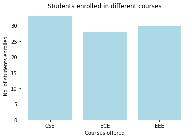

```python
import numpy as np
import matplotlib.pyplot as plt
# Dataset generation
data_dict = {'CSE':33, 'ECE':28, 'EEE':30}
courses   = list(data_dict.keys())
values    = list(data_dict.values())
fig = plt.figure()    # add option `figsize = (10, 5)` to control size
#  Bar plot
plt.box(False)              # get rid of the box
plt.bar(courses, values, color ='lightblue')
plt.xlabel("Courses offered")
plt.ylabel("No. of students enrolled")
plt.title("Students enrolled in different courses")
plt.show()
```

**Save a plot** to a file (.png or .pdf):

```
The file is saved to the current working directory:  /Users/luchens/Documents/jupyter-notebooks
```

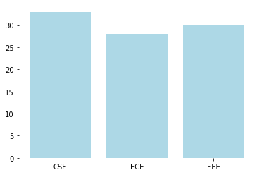

```python
fig = plt.figure()
plt.box(False)              # get rid of the box
plt.bar(courses, values, color ='lightblue')
fig.savefig('saved_figure-1000dpi.png', dpi = 1000, transparent=True)
# the plot is saved to the current working directory (cwd)
# to find out what the current working directory (cwd) is:
import os
print('The file is saved to the current working directory: ',os.getcwd())
```

To save the plot as a .pdf:

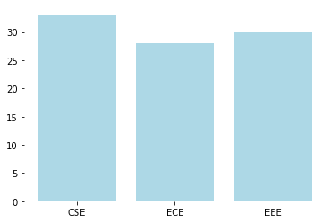

```python
fig = plt.figure()
plt.box(False)              # get rid of the box
plt.bar(courses, values, color ='lightblue')
fig.savefig('saved_figure-1000dpi.pdf', dpi = 1000, transparent=True)
```

Generate a **pie chart** for the same data (pie charts are usually a poor way to display data):

(documentation: https://matplotlib.org/stable/api/_as_gen/matplotlib.pyplot.pie.html )

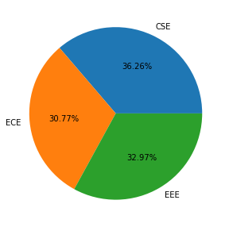

```python
import numpy as np
import matplotlib.pyplot as plt
# Dataset generation
data_dict = {'CSE':33, 'ECE':28, 'EEE':30}
courses   = list(data_dict.keys())
values    = list(data_dict.values())
fig = plt.figure(figsize = (10, 5))
# Pie chart:
plt.pie(values, labels=courses,autopct='%1.2f%%')   # option: autopct to show percentage; .1 means: 1 decimal
plt.show()
```

Generate a bar chart and a pie chart from an imported data set (students.csv):

Use `value_counts()` to count the how many times each of the values of the variable 'sex' in the dataframe 'df' occurs:

```python
a = df.sex.value_counts()
print(a)
```

```
Female    18
Male      12
Name: sex, dtype: int64
```

```python
a.values
```

```
array([18, 12])
```

```python
a.index
```

```
Index(['Female', 'Male'], dtype='object')
```

Then use `a` as input for the `bar()` function:

```
<BarContainer object of 2 artists>
```

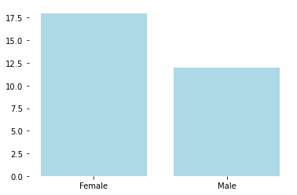

```python
plt.box(False)              # get rid of the box
plt.bar(a.index, a.values, color ='lightblue')
```

Or use `a` as input for the `pie()` function:

```
 [Text(-0.3399187721714582, 1.046162142464278, 'Female'),
 [Text(-0.18541023936624992, 0.5706338958896061, '60.0%'),
```

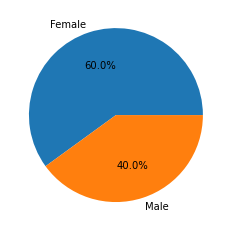

```python
plt.pie(a.values,labels=a.index,autopct='%1.1f%%')
```

### Contingency table

To create a contingency table use `pandas.crosstab(index, columns)`. For an example see: https://www.statology.org/contingency-table-python/ Here is how to create a contingency table for the categorical variables (sex, major) from the students data file stored in the datraframe called df:

```python
import pandas as pd
pd.crosstab(index=df['major'], columns=df['sex'],margins=True)
```

| sex major | Female | Male | All |
| --- | --- | --- | --- |
| Business | 9 | 6 | 15 |
| Communications | 4 | 1 | 5 |
| International Affairs | 4 | 5 | 9 |
| Other | 1 | 0 | 1 |
| All | 18 | 12 | 30 |

To express all frequencies as relative frequencies, divide by number of observations:

```python
n = len(df)    # number of observations
pd.crosstab(index=df['major'], columns=df['sex'],margins=True)/n
```

| sex major | Female | Male | All |
| --- | --- | --- | --- |
| Business | 0.300000 | 0.200000 | 0.500000 |
| Communications | 0.133333 | 0.033333 | 0.166667 |
| International Affairs | 0.133333 | 0.166667 | 0.300000 |
| Other | 0.033333 | 0.000000 | 0.033333 |
| All | 0.600000 | 0.400000 | 1.000000 |

… and multiply by 100 (percent) to get percentages:

```python
100*pd.crosstab(index=df['major'], columns=df['sex'],margins=True)/n
```

| sex major | Female | Male | All |
| --- | --- | --- | --- |
| Business | 30.000000 | 20.000000 | 50.000000 |
| Communications | 13.333333 | 3.333333 | 16.666667 |
| International Affairs | 13.333333 | 16.666667 | 30.000000 |
| Other | 3.333333 | 0.000000 | 3.333333 |
| All | 60.000000 | 40.000000 | 100.000000 |

Summary statistics (qualitative variables only):

```python
df.describe(include=['object'])
```

|  | sex | major |
| --- | --- | --- |
| count | 30 | 30 |
| unique | 2 | 4 |
| top | Female | Business |
| freq | 18 | 15 |

Summary statistics of one categorical variable (in this case: sex)

```python
df['sex'].describe()
```

```
count         30
unique         2
top       Female
freq          18
Name: sex, dtype: object
```

## Module 3: Displaying and describing quantitative variables

### Descriptive statistics (mean, median, standard deviation,…)

Summary statistics (all variables) using the `describe()` function from pandas:

```python
df.describe(include='all')
```

|  | case | sex | height | weight | major |
| --- | --- | --- | --- | --- | --- |
| count | 30.000000 | 30 | 30.000000 | 30.000000 | 30 |
| unique | NaN | 2 | NaN | NaN | 4 |
| top | NaN | Female | NaN | NaN | Business |
| freq | NaN | 18 | NaN | NaN | 15 |
| mean | 15.500000 | NaN | 174.033333 | 65.133333 | NaN |
| std | 8.803408 | NaN | 9.625696 | 13.356474 | NaN |
| min | 1.000000 | NaN | 154.000000 | 44.000000 | NaN |
| 25% | 8.250000 | NaN | 170.000000 | 54.000000 | NaN |
| 50% | 15.500000 | NaN | 172.000000 | 64.000000 | NaN |
| 75% | 22.750000 | NaN | 178.000000 | 74.250000 | NaN |
| max | 30.000000 | NaN | 195.000000 | 94.000000 | NaN |

Summary statistics of one variable (in this case: height) using the `describe()` function from pandas

```python
df['height'].describe()
```

```
count     30.000000
mean     174.033333
std        9.625696
min      154.000000
25%      170.000000
50%      172.000000
75%      178.000000
max      195.000000
Name: height, dtype: float64
```

Summary statistics (quantitative variables only) using the `describe()` function from pandas:

```python
df.describe()
```

|  | case | height | weight |
| --- | --- | --- | --- |
| count | 30.000000 | 30.000000 | 30.000000 |
| mean | 15.500000 | 174.033333 | 65.133333 |
| std | 8.803408 | 9.625696 | 13.356474 |
| min | 1.000000 | 154.000000 | 44.000000 |
| 25% | 8.250000 | 170.000000 | 54.000000 |
| 50% | 15.500000 | 172.000000 | 64.000000 |
| 75% | 22.750000 | 178.000000 | 74.250000 |
| max | 30.000000 | 195.000000 | 94.000000 |

**Mean** and **standard deviation** of one of the variables ('height') from the 'df' dataframe:

```python
import pandas as pd
df.height.mean()                        # height.mean() does not work: NameError: name 'height' is not defined
```

```
174.03333333333333
```

```python
df.height.std()
```

```
9.625695974240289
```

Other descriptive statistics:

```python
df.height.median()   # simularly: min() ; max() ; sum() ; count() ; quantile()
```

```
172.0
```

```python
df.height.quantile(q=0.50)   # the 50th percentile is the same as the median
```

```
172.0
```

```python
df.height.quantile(q=0.25)  # the 25th percentile (the first quartile)
```

```
170.0
```

```python
df.height.quantile(q=0.75)  # the 75th percentile (the third quartile)
```

```
178.0
```

```python
df.height.quantile(q=0.75)-df.height.quantile(q=0.25) # the interquartile range (IQR)
```

```
8.0
```

### Histogram

To draw a **histogram** use `hist()` from the `matplotlib.pyplot` library.

**Frequency histogram** (vertical axis shows counts, absolute frequencies):

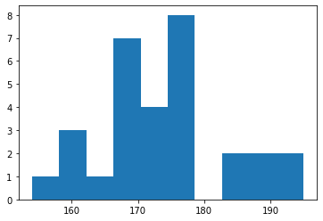

```python
import matplotlib.pyplot as plt
plt.hist(df.height)    # the default is a frequency histogram: vertical axis shows counts (absolute frequencies)
```

Get rid of the box, add labels to the axes, and let the bins start at 150, 155, 160,...:

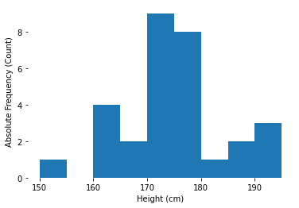

```python
import matplotlib.pyplot as plt
plt.box(False)              # get rid of the box
plt.xlabel('Height (cm)')   # add label on x-axis
plt.ylabel('Absolute Frequency (Count)')     # add label on x-axis
plt.hist(df.height,bins=[150,155,160,165,170,175,180,185,190,195])
```

**Relative frequency histogram** (vertical axis shows relative frequencies):

```python
df.height.size  # size gives the number of observations of the variable height
```

```
30
```

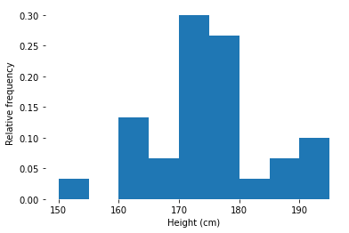

```python
import matplotlib.pyplot as plt
import numpy as np
plt.box(False)              # get rid of the box
plt.xlabel('Height (cm)')   # add label on x-axis
plt.ylabel('Relative frequency')     # add label on x-axis
plt.hist(df.height, weights=np.zeros_like(df.height) + 1. / df.height.size,
         bins=[150,155,160,165,170,175,180,185,190,195])
```

To get a relative frequency histogram with relative frequencies expressed as percentages, multiply the weights by 100:

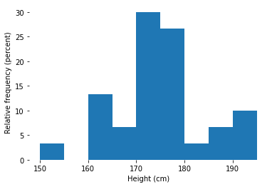

```python
import matplotlib.pyplot as plt
import numpy as np
df.height.size  # size gives the number of observations of the variable height
plt.box(False)              # get rid of the box
plt.xlabel('Height (cm)')   # add label on x-axis
plt.ylabel('Relative frequency (percent)')     # add label on x-axis
plt.hist(df.height, weights=100*(np.zeros_like(df.height) + 1. / df.height.size),
         bins=[150,155,160,165,170,175,180,185,190,195])
```

**Density histogram** (vertical axis shows densities):

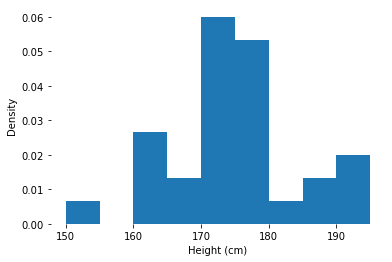

```python
import matplotlib.pyplot as plt
df.height.size  # size gives the number of observations of the variable height
plt.box(False)              # get rid of the box
plt.xlabel('Height (cm)')   # add label on x-axis
plt.ylabel('Density')     # add label on x-axis
plt.hist(df.height, density=True, bins=[150,155,160,165,170,175,180,185,190,195])
```

### Box plot

Use `boxplot()` from `matplotlib`:

```
{'whiskers': [<matplotlib.lines.Line2D at 0x7f87f053acd0>,
 'caps': [<matplotlib.lines.Line2D at 0x7f88104ba250>,
 'boxes': [<matplotlib.lines.Line2D at 0x7f87f053a8e0>],
 'medians': [<matplotlib.lines.Line2D at 0x7f88104ba940>],
 'fliers': [<matplotlib.lines.Line2D at 0x7f88104bacd0>],
 'means': []}
```

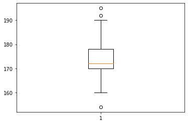

```python
import matplotlib.pyplot as plt
plt.boxplot(df.height)
```

Rotate the boxplot to get a horizontal orientation:

```
{'whiskers': [<matplotlib.lines.Line2D at 0x7f88234b8970>,
 'caps': [<matplotlib.lines.Line2D at 0x7f88234c60d0>,
 'boxes': [<matplotlib.lines.Line2D at 0x7f88234b85e0>],
 'medians': [<matplotlib.lines.Line2D at 0x7f88234c6790>],
 'fliers': [<matplotlib.lines.Line2D at 0x7f88234c6b20>],
 'means': []}
```

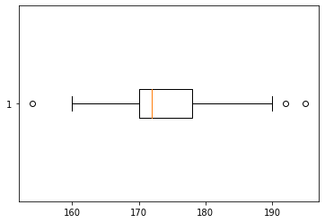

```python
import matplotlib.pyplot as plt
plt.boxplot(df.height,vert=False)
```

Make the box plot prettier (get rid of the box, label the axis, add a title, get rid of the "1" tick):

```
{'whiskers': [<matplotlib.lines.Line2D at 0x7f87f070c220>,
 'caps': [<matplotlib.lines.Line2D at 0x7f87f070c940>,
 'boxes': [<matplotlib.lines.Line2D at 0x7f87f06fde50>],
 'medians': [<matplotlib.lines.Line2D at 0x7f87f071a040>],
 'fliers': [<matplotlib.lines.Line2D at 0x7f87f071a3d0>],
 'means': []}
```

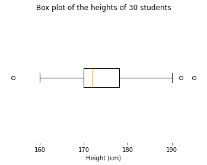

```python
import matplotlib.pyplot as plt
plt.box(False)             # get rid of the box
plt.title("Box plot of the heights of 30 students") # add title
plt.xlabel("Height (cm)")  # add label to x-axis
plt.ylabel("")
plt.tick_params(   # this block removes the "1" tick
    axis='y',          # changes apply to the y-axis
    which='both',      # both major and minor ticks are affected
    left=False,        # ticks along the left edge are off    (for x axis use: bottom)
    right=False,       # ticks along the right edge are off   (for x axis use: top   )
    labelleft=False)   # labels along the left edge are off   (for x axis use: bottom)
plt.boxplot(df.height,vert=False)
```

To compare the heights of men and women, use **side-by-side boxplots** (from the `seaborn` library):

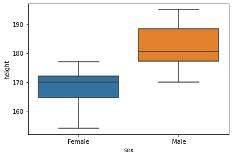

```python
import seaborn as sns
sns.boxplot(data=df,x="sex",y='height')
```

```python
df.sex.count()
```

```
30
```

## Module 4: Correlation and Regression

Make a **scatter plot** of heights (horizontal axis) and weights (vertical axis) using `scatter()` from `matplotlib.pyplot`:

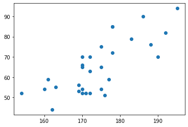

```python
import numpy as np
import matplotlib.pyplot as plt
plt.scatter(df.height,df.weight)
```

Make the scatter plot prettier (get rid of the box, add labels to the axes):

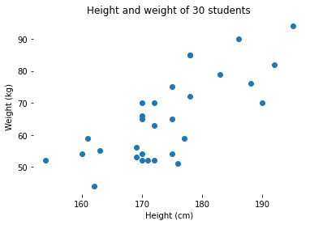

```python
plt.box(False)             # get rid of the box
plt.title("Height and weight of 30 students") # add title
plt.xlabel("Height (cm)")  # add label to x-axis
plt.ylabel("Weight (kg)")  # add label to y-axis
plt.scatter(df.height,df.weight)
```

Correlation coefficient:

```python
# correlation between height and weight:
df.height.corr(df.weight)
```

```
0.7525668130284301
```

```python
# correlation matrix between all quantitative variables of a data frame:
df.corr()
```

|  | case | height | weight |
| --- | --- | --- | --- |
| case | 1.000000 | -0.320457 | -0.254260 |
| height | -0.320457 | 1.000000 | 0.752567 |
| weight | -0.254260 | 0.752567 | 1.000000 |

To get *one* of the correlation coefficients, first convert to matrix:

```python
import numpy as np
corr_matrix = np.array(df.corr())
print(corr_matrix)
```

```
[[ 1.         -0.32045686 -0.25426022]
 [-0.32045686  1.          0.75256681]
 [-0.25426022  0.75256681  1.        ]]
```

```python
# extract the correlation between height and weight (caution: rows and columns start counting at 0):
corr_matrix[1][2]
```

```
0.7525668130284303
```

To round numbers, use `round()` from the numpy library:

```python
import numpy as np
np.round(_,2)   # in Python, _ is the output of the last cell; the second argument is the number of decimals
```

```
0.75
```

Find the **line of best fit** (using the ordinary least squares method) using `statsmodels`:

```python
import statsmodels.api as sms
import statsmodels.formula.api as smf
# Fit regression model:
results = smf.ols('df.weight ~ df.height', data=df).fit()
# Inspect the results:
print(results.summary())
```

```
                            OLS Regression Results
==============================================================================
Dep. Variable:              df.weight   R-squared:                       0.566
Model:                            OLS   Adj. R-squared:                  0.551
Method:                 Least Squares   F-statistic:                     36.57
Date:                Fri, 14 Jan 2022   Prob (F-statistic):           1.61e-06
Time:                        09:30:38   Log-Likelihood:                -107.29
No. Observations:                  30   AIC:                             218.6
Df Residuals:                      28   BIC:                             221.4
Df Model:                           1
Covariance Type:            nonrobust
==============================================================================
                 coef    std err          t      P>|t|      [0.025      0.975]
------------------------------------------------------------------------------
Intercept   -116.6011     30.097     -3.874      0.001    -178.252     -54.951
df.height      1.0443      0.173      6.047      0.000       0.691       1.398
==============================================================================
Omnibus:                        2.804   Durbin-Watson:                   2.486
Prob(Omnibus):                  0.246   Jarque-Bera (JB):                1.333
Skew:                           0.007   Prob(JB):                        0.514
Kurtosis:                       1.968   Cond. No.                     3.21e+03
==============================================================================

Notes:
[1] Standard Errors assume that the covariance matrix of the errors is correctly specified.
[2] The condition number is large, 3.21e+03. This might indicate that there are
strong multicollinearity or other numerical problems.
```

To get just the coefficients:

```python
results.params
```

```
Intercept   -116.601087
df.height      1.044251
dtype: float64
```

The intercept is the first coefficient:

```python
results.params[0]
```

```
-116.6010867272883
```

The slope coefficient is the second coefficient:

```python
results.params[1]
```

```
1.044250641987867
```

To get the *t*-values of the coefficients (Statistics II):

```python
results.tvalues
```

```
Intercept   -3.874200
df.height    6.047248
dtype: float64
```

To get the *p*-values of the coefficients (Statistics II):

```python
results.pvalues
```

```
Intercept    0.000588
df.height    0.000002
dtype: float64
```

Add line of best fit to the scatter plot (see: https://stackoverflow.com/questions/7941226/how-to-add-line-based-on-slope-and-intercept-in-matplotlib):

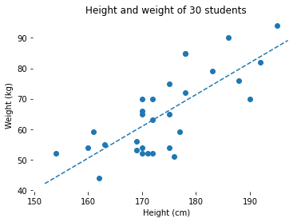

```python
import matplotlib.pyplot as plt
import numpy as np
import statsmodels.api as sms
import statsmodels.formula.api as smf

# Fit regression model:
results = smf.ols('df.weight ~ df.height', data=df).fit()

def abline(slope, intercept):
    """Plot a line from slope and intercept"""
    axes = plt.gca()
    x_vals = np.array(axes.get_xlim())
    y_vals = intercept + slope * x_vals
    plt.plot(x_vals, y_vals, '--')

plt.box(False)             # get rid of the box
plt.title("Height and weight of 30 students") # add title
plt.xlabel("Height (cm)")  # add label to x-axis
plt.ylabel("Weight (kg)")  # add label to y-axis
plt.scatter(df.height,df.weight)
abline(results.params[1],results.params[0])     # add line y=a*x+b  (a = slope, b = intercept)
```

The **`seaborn`** library has more sophisticated ways to visualize data. For instance, to add a line of best fit with a 95 percent confidence interval to the scatter plot:

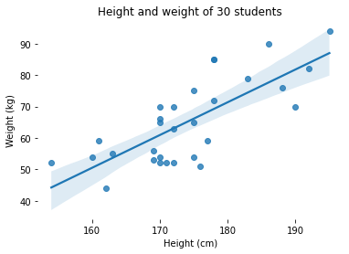

```python
import seaborn as sns
sns.regplot(x=df.height,y=df.weight, data=df) # regplot: regression plot
plt.box(False)             # get rid of the box
plt.title("Height and weight of 30 students") # add title
plt.xlabel("Height (cm)")  # add label to x-axis
plt.ylabel("Weight (kg)")  # add label to y-axis
plt.show()
```

## Module 5: Randomness and Probability

(No Python code for this module.)

## Module 6: Random variables and probability models

The `scipy` library (scientific computing in Python) has the functions to work with discrete and continuous probability models (https://scipy.org).

Calculate **binomial probability** (*k* = number of successes, *n* = number of trials, *p* = probability of success) (`pmf` stands for probability mass function—like pdf but for a discrete random variable):

```python
# calculate binomial probability (k= number of successes, n = number of trials, p = probability of success)
from scipy.stats import binom
binom.pmf(k=10, n=12, p=0.6)   # pmf: probability mass function (like pdf but for a discrete random variable)
```

```
0.063852281856
```

Calculate cumulative binomial probability:

```python
from scipy.stats import binom
binom.cdf(k=10, n=12, p=0.6)
```

```
0.980408958976
```

## Module 7: The Normal distribution

Plot the **probability density function** (pdf) of the normal curve (https://www.statology.org/plot-normal-distribution-python/):

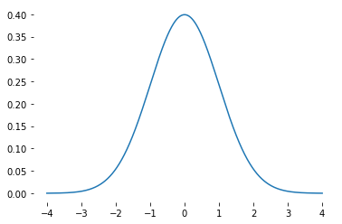

```python
import numpy as np
import matplotlib.pyplot as plt
from scipy.stats import norm
# x-axis ranges from -4 and 4 with .001 steps:
x = np.arange(-4, 4, 0.001)

# plot normal distribution with mean 0 and standard deviation 1
plt.box(False) # get rid of the box around the plot
plt.plot(x, norm.pdf(x, 0, 1))
```

To change color, linewidth, linestyle:

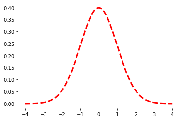

```python
plt.box(False) # get rid of the box around the plot
plt.plot(x, norm.pdf(x, 0, 1), color='red', linewidth=3, linestyle='dashed')
```

### Area under normal curve:

To find an area under the normal curve, use the **cumulative density function** (cdf) of the normal distribution. (documentation: see: https://docs.scipy.org/doc/scipy/reference/stats.html)

```python
import numpy as np
import matplotlib.pyplot as plt
from scipy.stats import norm
mu    = 0     # mean               (for the standard normal distribution, the mean = 0)
sigma = 1     # standard deviation (for the standard normal distribution, the standard deviation = 1)
x1 = -1.96    # lower boundary
x2 = 1.96   # lower boundary
# area under normal curve between x1 and x2:
area = norm.cdf(x2, loc=mu, scale=sigma)-norm.cdf(x1, loc=mu, scale=sigma)
print('The area under the normal curve is', area)
```

```
The area under the normal curve is 0.950004209703559
```

To **plot** the area under the normal curve (see: https://pythonforundergradengineers.com/plotting-normal-curve-with-python.html)

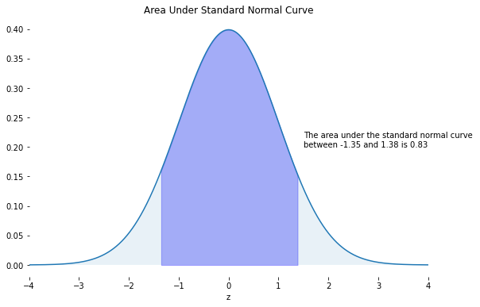

```
The area under the standard normal curve between -1.35 and 1.38 is 0.83.
```

```python
import numpy as np
import matplotlib.pyplot as plt
from scipy.stats import norm
# define constants
mu = 998.8 # mean
sigma = 73.10  # standard deviation
x1 = 900    # lower boundary
x2 = 1100   # lower boundary
# calculate the standardized values:
z1 = ( x1 - mu )/ sigma
z2 = ( x2 - mu) / sigma
x = np.arange(z1, z2, 0.001) # range of x in spec
x_all = np.arange(-10, 10, 0.001) # entire range of x, both in and out of spec
# for standard normal distribution, mean = 0, stddev = 1:
y = norm.pdf(x,0,1)
y2 = norm.pdf(x_all,0,1)
# find area under normal curve between x1 and x2:
area = norm.cdf(x2, loc=mu, scale=sigma)-norm.cdf(x1, loc=mu, scale=sigma)

# build the plot
fig, ax = plt.subplots(figsize=(9,6))
ax.plot(x_all,y2)
ax.fill_between(x,y,0, alpha=0.3, color='b')
ax.fill_between(x_all,y2,0, alpha=0.1)
ax.set_xlim([-4,4])
ax.set_xlabel('z')
# ax.set_yticklabels([])
ax.set_title('Area Under Standard Normal Curve')
plt.box(False)
plt.text(1.5,0.2, f"The area under the standard normal curve \nbetween {np.round(z1,2)} and {np.round(z2,2)} is {np.round(area,2)}")
plt.savefig('normal_curve.png', dpi=72, bbox_inches='tight')
plt.show()

print(f"The area under the standard normal curve between {np.round(z1,2)} and {np.round(z2,2)} is {np.round(area,2)}.")
```

### Other continuous distributions

Uniform distribution (https://docs.scipy.org/doc/scipy/reference/generated/scipy.stats.uniform.html):

```python
from scipy.stats import uniform
# In the standard form, the distribution is uniform on [0, 1].
# Using the parameters loc and scale, one obtains the uniform distribution on [loc, loc + scale].
uniform.cdf(0.9)
```

```
0.9
```

**Student *t*** distribution (covered in Statistics II)

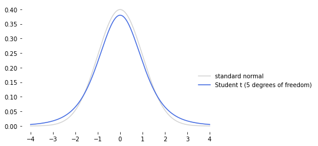

```python
import numpy as np
import matplotlib.pyplot as plt
from scipy.stats import t
dof = 5   # degrees of freedom of Student t distribution
# x-axis ranges from -4 and 4 with .001 steps:
x = np.arange(-4, 4, 0.001)
plt.figure()
plt.box(False)
plt.plot(x, norm.pdf(x,0,1 ), color="lightgrey")     # plot the standard normal curve as a benchmark
plt.plot(x, t.pdf(x, dof)     , color="royalblue")   # the second argument is the degrees of freedom
plt.legend(["standard normal" , f"Student t ({dof} degrees of freedom)"], loc="upper right", bbox_to_anchor = (1.5,0.5), edgecolor="None")
# plt.text(3.5,0.35, f"({dof} degrees of freedom)")
plt.show()
```

Plot Student *t* distributions with different degrees of freedom and compare with standard normal distribution (see Haslwanter (2016), p. 110) in an interactive diagram where you can change the degrees of freedom with a slider:

(Normally the `ipywidgets` library is installled in Anacanda. If that is not the case, remove the hashtag at the beginning of the following line and run the line: `pip install ipywidgets`.)

```python
import numpy as np
import matplotlib.pyplot as plt
from scipy.stats import norm, t
from ipywidgets import interact # import ipywidgets.interact class. This class will represent a slide bar.
# x-axis ranges from -4 to 4 with steps of .001 :
x = np.arange(-4, 4, 0.001)
# use interact decorator to decorate the function,
# so the function can receive the slide bar's value with the parameter (in this case: dof).
@interact(dof=(1,60,1))
def plt_t(dof):
    plt.figure()
    plt.box(False)
    plt.plot(x, norm.pdf(x,0,1 ), color="lightgrey")    # plot the standard normal curve as a benchmark
    plt.plot(x, t.pdf(x, dof)   , color="royalblue")    # plot Student t distribution (dof = degrees of freedom)
    plt.legend(["standard normal" , "Student $\it{t}$"], loc="upper right", edgecolor="None")
    plt.show
```

To find an area under the Student t curve, use the **cumulative density function** (cdf) of the Student t distribution (documentation: see: https://docs.scipy.org/doc/scipy/reference/stats.html):

```python
import numpy as np
from scipy.stats import t
dof = 30      # degrees of freedom
t1 = -1.00   # lower boundary
t2 =  1.00   # lower boundary
# area under Student t curve between t1 and t2:
area = t.cdf(t2,dof)-t.cdf(t1,dof)
print(f'The area under the Student t curve with {dof} degrees of freedom between {t1} and {t2} is {area}')
```

```
The area under the Student t curve with 30 degrees of freedom between -1.0 and 1.0 is 0.6746913845739702
```

(To **plot** the area, adapt the code above to plot the area under the normal curve.)

## Module 9: Sampling Distributions and Confidence Intervals for Proportions

To find the **confidence interval for a proportion**: (https://www.statsmodels.org/dev/generated/statsmodels.stats.proportion.proportion_confint.html)

```python
310 / 1126    # sample proportion = p=hat = number of successes / number of trials

import statsmodels.api as sm
from statsmodels.stats.proportion import proportion_confint   # Function for computing confidence intervals

proportion_confint(count=310,        # count= number of successes
                   nobs=1126,        # nobs = number of trials
                   alpha=(1 - 0.95)) # alpha =  1 - confidence level
```

```
(0.24922129423231776, 0.30140037539468045)
```

## Module 10: Sampling Distributions and Confidence Intervals for Means

To find the **confidence interval for a mean** (in this case: the mean height of all students in the dataframe df):

```python
import numpy as np
import scipy.stats as stats

degrees_of_freedom    = len(df)-1           # degrees of freedom = sample size-1
sample_mean           = np.mean(df.height)  # sample mean
sample_standard_error = stats.sem(df.height)   # sample standard error of mean

# create confidence interval for the population mean:
stats.t.interval(alpha=0.05, df=degrees_of_freedom, loc=sample_mean, scale=sample_standard_error)
```

```
(173.9221744669485, 174.14449219971817)
```

## Hypothesis tests (Statistics II)

For hypothesis tests (covered in Statistics II), see: https://www.statsmodels.org/stable/stats.html

## Interacting with the operating system (changing current working directory etc.)

The `os` library allows you to interact with the operating system using Python code.

The **current working directory** (cwd) is where Python will look for input (such as data files) and where it will store output (such as .png or .pdf figures and tables with results). To find out what the current working directory of Python is:

```python
import os
print(os.getcwd())
```

```
/Users/luchens/Documents/jupyter-notebooks
```

If you want to change the current working directory, use the chdir command of the `os` library to do so. Here is how to change the current working directory (the expression in quotes is the path to the new working directory — it will be a different path for you, of course):

```python
os.chdir('/Users/luchens/Documents/Data/')
print(os.getcwd())
```

```
/Users/luchens/Documents/Data
```

To display the files and directories in the working directory, use `os.listdir()`